# Lab_2 Group_Assigment

Group_6 : Anton, Atom, Clarence, Mary, Park, Dongwon

## Iris dataset

Iris, introduced by Ronald Fisher in his 1936 paper The use of multiple measurements in taxonomic problems, contains three plant species (setosa, virginica, versicolor) and four features measured for each sample. These quantify the morphologic variation of the iris flower in its three species, all measurements given in centimeters.

### First lets explore datset

```r
library("tidyverse")
```

```r
library("cowplot")
library("GGally")
library("corrplot")
data(iris)
head(iris)
```

|  | Sepal.Length | Sepal.Width | Petal.Length | Petal.Width | Species |
| --- | --- | --- | --- | --- | --- |
| 1 | 5.1 | 3.5 | 1.4 | 0.2 | setosa |
| 2 | 4.9 | 3.0 | 1.4 | 0.2 | setosa |
| 3 | 4.7 | 3.2 | 1.3 | 0.2 | setosa |
| 4 | 4.6 | 3.1 | 1.5 | 0.2 | setosa |
| 5 | 5.0 | 3.6 | 1.4 | 0.2 | setosa |
| 6 | 5.4 | 3.9 | 1.7 | 0.4 | setosa |

```r
summary(iris)
```

```
##   Sepal.Length    Sepal.Width     Petal.Length    Petal.Width
##  Min.   :4.300   Min.   :2.000   Min.   :1.000   Min.   :0.100
##  1st Qu.:5.100   1st Qu.:2.800   1st Qu.:1.600   1st Qu.:0.300
##  Median :5.800   Median :3.000   Median :4.350   Median :1.300
##  Mean   :5.843   Mean   :3.057   Mean   :3.758   Mean   :1.199
##  3rd Qu.:6.400   3rd Qu.:3.300   3rd Qu.:5.100   3rd Qu.:1.800
##  Max.   :7.900   Max.   :4.400   Max.   :6.900   Max.   :2.500
##        Species
##  setosa    :50
##  versicolor:50
##  virginica :50
##
##
##
```

```r
setosa = filter(iris, Species == 'setosa')
versicolor = filter(iris, Species == 'versicolor')
virginica = filter(iris,Species == 'virginica')
summary(setosa)
```

```
##   Sepal.Length    Sepal.Width     Petal.Length    Petal.Width
##  Min.   :4.300   Min.   :2.300   Min.   :1.000   Min.   :0.100
##  1st Qu.:4.800   1st Qu.:3.200   1st Qu.:1.400   1st Qu.:0.200
##  Median :5.000   Median :3.400   Median :1.500   Median :0.200
##  Mean   :5.006   Mean   :3.428   Mean   :1.462   Mean   :0.246
##  3rd Qu.:5.200   3rd Qu.:3.675   3rd Qu.:1.575   3rd Qu.:0.300
##  Max.   :5.800   Max.   :4.400   Max.   :1.900   Max.   :0.600
##        Species
##  setosa    :50
##  versicolor: 0
##  virginica : 0
##
##
##
```

```r
summary(versicolor)
```

```
##   Sepal.Length    Sepal.Width     Petal.Length   Petal.Width          Species
##  Min.   :4.900   Min.   :2.000   Min.   :3.00   Min.   :1.000   setosa    : 0
##  1st Qu.:5.600   1st Qu.:2.525   1st Qu.:4.00   1st Qu.:1.200   versicolor:50
##  Median :5.900   Median :2.800   Median :4.35   Median :1.300   virginica : 0
##  Mean   :5.936   Mean   :2.770   Mean   :4.26   Mean   :1.326
##  3rd Qu.:6.300   3rd Qu.:3.000   3rd Qu.:4.60   3rd Qu.:1.500
##  Max.   :7.000   Max.   :3.400   Max.   :5.10   Max.   :1.800
```

```r
summary(virginica)
```

```
##   Sepal.Length    Sepal.Width     Petal.Length    Petal.Width
##  Min.   :4.900   Min.   :2.200   Min.   :4.500   Min.   :1.400
##  1st Qu.:6.225   1st Qu.:2.800   1st Qu.:5.100   1st Qu.:1.800
##  Median :6.500   Median :3.000   Median :5.550   Median :2.000
##  Mean   :6.588   Mean   :2.974   Mean   :5.552   Mean   :2.026
##  3rd Qu.:6.900   3rd Qu.:3.175   3rd Qu.:5.875   3rd Qu.:2.300
##  Max.   :7.900   Max.   :3.800   Max.   :6.900   Max.   :2.500
##        Species
##  setosa    : 0
##  versicolor: 0
##  virginica :50
##
##
##
```

### Visualization and Analysis

#### Chart_1

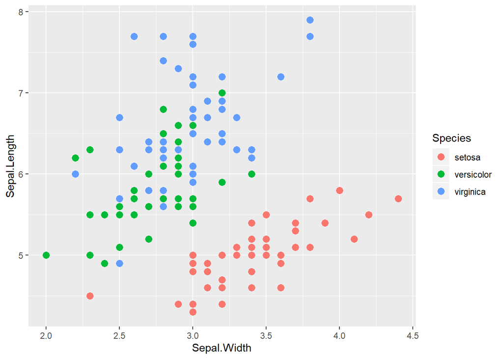

```r
ggplot(iris, aes(y = Sepal.Length , x = Sepal.Width)) + geom_point(aes(color = Species), size = 3)
```

#### Analysis/Comments

From the Chart above, we can figure out that distribution of sepal length and width by species, setosa, versicolor, and virginica. According to graph, with the same width, in general, setosa has shorter length, and virginica has longer length. Plus, we can also figure out that sepal width and length has correlation between width and length.

#### Chart_2

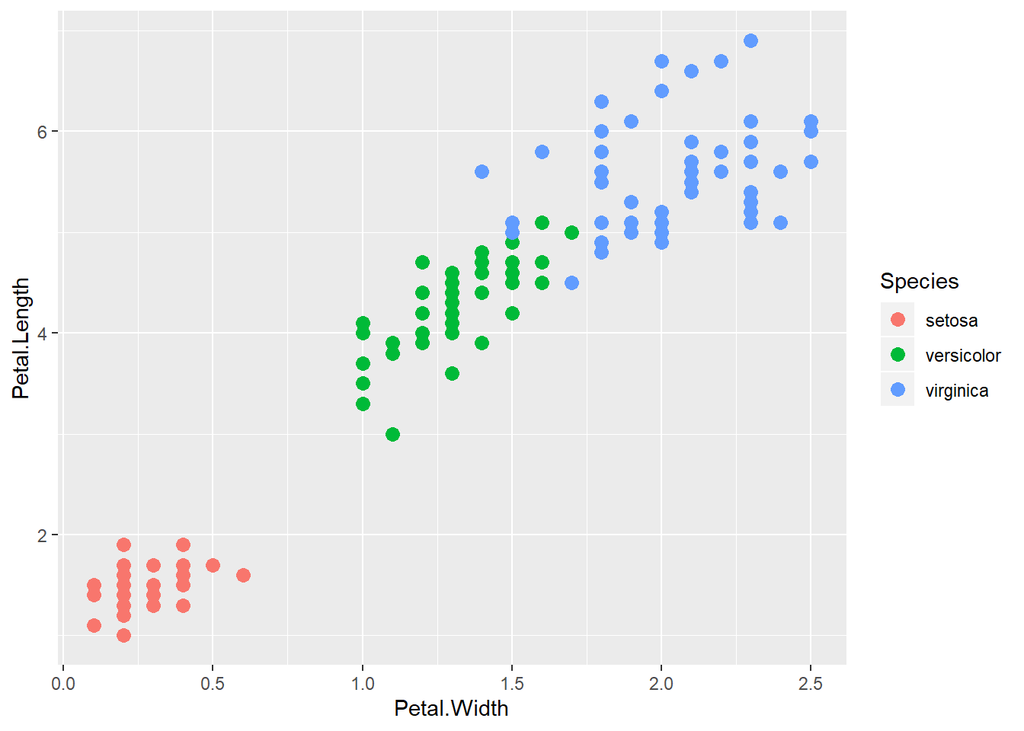

```r
ggplot(iris, aes(y = Petal.Length , x = Petal.Width)) + geom_point(aes(color = Species), size = 3)
```

#### Analysis/Comments

This graph shows petal width and length by species. As we can see above, it shows same pattern with the above sepal length and width graph. In other words, petal shows correlation between width and length and, in general, virginica has larger width and length than setosa and versicolor.

#### Chart_3

```r
d1 = ggplot( data=iris, aes(x=Sepal.Width, color = Species)) +
  geom_histogram(fill="skyblue", alpha=0.5,binwidth=0.2) +
  theme_minimal()
d2 = ggplot( data=iris, aes(x=Sepal.Length, color = Species)) +
  geom_histogram(fill="skyblue", alpha=0.5,binwidth=0.2) +
  theme_minimal()

d3 = ggplot( data=iris, aes(x=Petal.Width, color = Species)) +
  geom_histogram(fill="skyblue", alpha=0.5,binwidth=0.2) +
  theme_minimal()
d4 = ggplot( data=iris, aes(x=Petal.Length, color = Species)) +
  geom_histogram(fill="skyblue", alpha=0.5,binwidth=0.2) +
  theme_minimal()
```

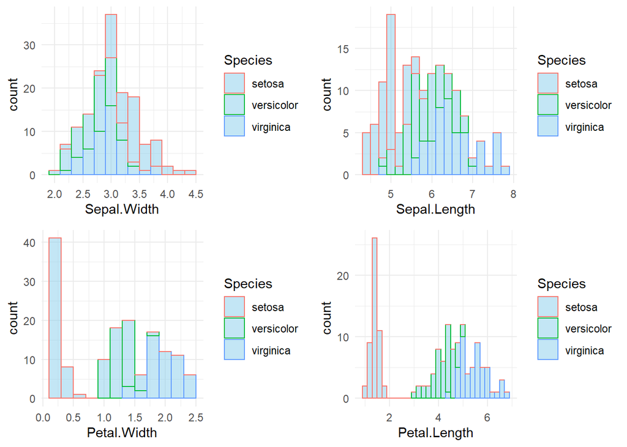

```r
plot_grid(d1, d2, d3, d4 ,
#          labels = c("A", "B", "C",'D'),
          ncol = 2, nrow = 2)
```

#### Analysis/Comments

We can convert scatter graph to histogram. From the histogram we can see distribution of each species, however, hard to see correlation between width and length. Since each graph has strength and weakness, need to choose proper the graph according to the data type and distribution.

## Overall Chart

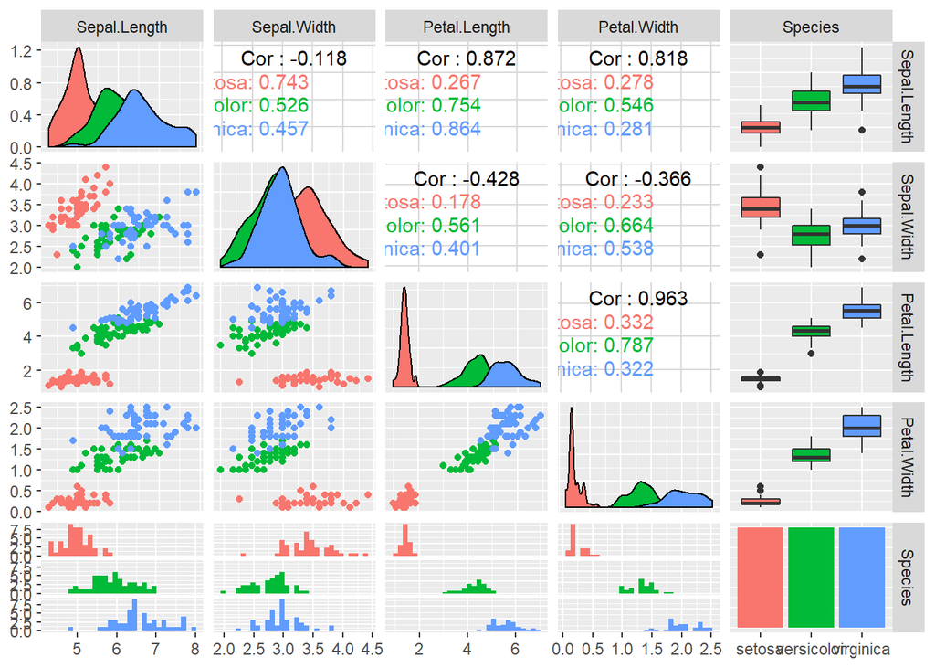

```r
ggpairs(iris, mapping=ggplot2::aes(colour=Species))
```

## Mtcars dataset

MTcars data set has data on the design, performance and fuel economy for 32 automobiles from 1973 - 1974. All of the data therein was extracted from the 1974 Motor Trend US magazine.

### First lets explore datset

```r
data("mtcars")
head(mtcars)
```

|  | mpg | cyl | disp | hp | drat | wt | qsec | vs | am | gear | carb |
| --- | --- | --- | --- | --- | --- | --- | --- | --- | --- | --- | --- |
| Mazda RX4 | 21.0 | 6 | 160 | 110 | 3.90 | 2.620 | 16.46 | 0 | 1 | 4 | 4 |
| Mazda RX4 Wag | 21.0 | 6 | 160 | 110 | 3.90 | 2.875 | 17.02 | 0 | 1 | 4 | 4 |
| Datsun 710 | 22.8 | 4 | 108 | 93 | 3.85 | 2.320 | 18.61 | 1 | 1 | 4 | 1 |
| Hornet 4 Drive | 21.4 | 6 | 258 | 110 | 3.08 | 3.215 | 19.44 | 1 | 0 | 3 | 1 |
| Hornet Sportabout | 18.7 | 8 | 360 | 175 | 3.15 | 3.440 | 17.02 | 0 | 0 | 3 | 2 |
| Valiant | 18.1 | 6 | 225 | 105 | 2.76 | 3.460 | 20.22 | 1 | 0 | 3 | 1 |

```r
summary(mtcars)
```

```
##       mpg             cyl             disp             hp
##  Min.   :10.40   Min.   :4.000   Min.   : 71.1   Min.   : 52.0
##  1st Qu.:15.43   1st Qu.:4.000   1st Qu.:120.8   1st Qu.: 96.5
##  Median :19.20   Median :6.000   Median :196.3   Median :123.0
##  Mean   :20.09   Mean   :6.188   Mean   :230.7   Mean   :146.7
##  3rd Qu.:22.80   3rd Qu.:8.000   3rd Qu.:326.0   3rd Qu.:180.0
##  Max.   :33.90   Max.   :8.000   Max.   :472.0   Max.   :335.0
##       drat             wt             qsec             vs
##  Min.   :2.760   Min.   :1.513   Min.   :14.50   Min.   :0.0000
##  1st Qu.:3.080   1st Qu.:2.581   1st Qu.:16.89   1st Qu.:0.0000
##  Median :3.695   Median :3.325   Median :17.71   Median :0.0000
##  Mean   :3.597   Mean   :3.217   Mean   :17.85   Mean   :0.4375
##  3rd Qu.:3.920   3rd Qu.:3.610   3rd Qu.:18.90   3rd Qu.:1.0000
##  Max.   :4.930   Max.   :5.424   Max.   :22.90   Max.   :1.0000
##        am              gear            carb
##  Min.   :0.0000   Min.   :3.000   Min.   :1.000
##  1st Qu.:0.0000   1st Qu.:3.000   1st Qu.:2.000
##  Median :0.0000   Median :4.000   Median :2.000
##  Mean   :0.4062   Mean   :3.688   Mean   :2.812
##  3rd Qu.:1.0000   3rd Qu.:4.000   3rd Qu.:4.000
##  Max.   :1.0000   Max.   :5.000   Max.   :8.000
```

### Visualization and Analysis

```r
mtcars$gear = factor(mtcars$gear,levels=c(3,4,5),
   labels=c("3_Gears","4_Gears","5_Gears"))
```

#### Chart_1 Distribution of Gas Milage

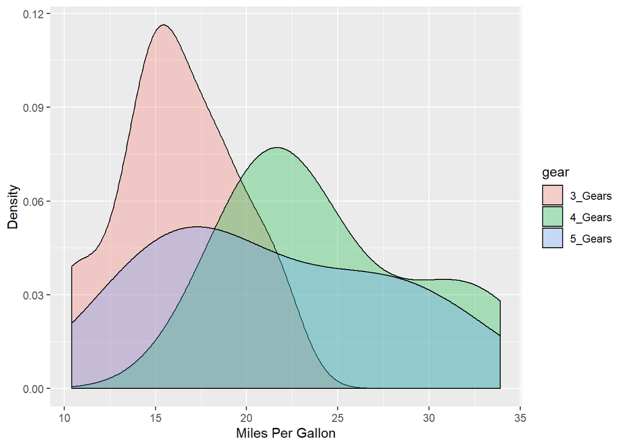

```r
qplot(mpg, data=mtcars, geom="density", fill=gear, alpha=I(0.3),
   xlab="Miles Per Gallon",   ylab="Density")
```

#### Analysis/Comments

From the graph above, we can analyze distribution by gears. 5_gear shows higher miles per gallon than 3_gear, however, lower than 4_gear. Plus, although this graph helps to read relation between mean, mode, and skew, it will be more clear if nomarlize the distribution.

#### Chart_2 Mileage by Gear Number

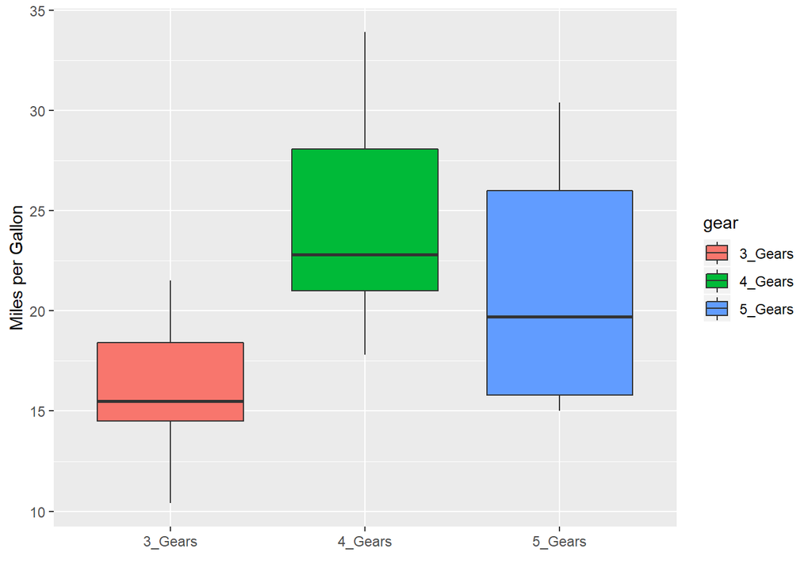

```r
qplot(gear, mpg, data=mtcars, geom=c("boxplot"),
   fill=gear,   xlab="", ylab="Miles per Gallon")
```

#### Analysis/Comments

This graph shows quartile distribution. We can see 25%, median, and 75% value more clearly compare to distribution density graph. Moreover, we can understand this data has no outlier. Even box plot shows some calculated values more clearly, it’s more convenient to see overall aspect with density distribution graph.